# Análise do desempenho no SAT (1994-1995)

Autor

João Victor Magalhães Matusalen

## Introdução

Este trabalho analisa dados estaduais do SAT (Scholastic Assessment Test) no período de 1994-1995.

O SAT é um exame educacional padronizado aplicado a estudantes do Ensino Médio nos Estados Unidos e utilizado como um dos critérios de admissão em universidades norte-americanas. Embora seja frequentemente comparado ao ENEM brasileiro, o processo de admissão universitária nos Estados Unidos não depende somente da nota obtida no exame.

O banco de dados utilizado neste trabalho reúne informações de 50 observações, correspondentes aos estados norte-americanos, com `4`variáveis explicativas e `1`variável resposta:

- Variável resposta:
  - `total`: média do total de pontos obtidos no SAT.
- Variáveis explicativas:
  - `salario`: faixa salarial anual ( mil dólares) de professores de escolas públicas elementares e secundárias (1: inferior à 30; 2: entre 30 e 40; 3: superior à 40);
  - `despesa`: despesas correntes (mil dólares) médias por aluno de escolas públicas primárias e secundárias;
  - `razão`: razão média de alunos/professores de escolas públicas elementares e secundárias;
  - `percentual`: percentual de alunos aptos que realizaram o exame;

A questão central é avaliar se variáveis ligadas à educação pública estão associadas ao desempenho médio no SAT.

## Análise dos dados

De inicio para desvendar a base e entender nossos dados, vamos carregar para dentro do R, trazer descritivas sobre as váriaveis e plotar usando o `GGally:ggpairs` a tabela de correlação.

**Código**

```r
library(tidyverse)
library(knitr)
library(GGally)

#Importando os dados

dados <- read.csv("data/SAT.csv") |> as_tibble()

dados
```

```
# A tibble: 50 × 5
   total salario percentual despesa razao
   <int>   <int>      <int>   <dbl> <dbl>
 1  1029       1          8    4.40  17.2
 2   934       3         47    8.96  17.6
 3   944       2         27    4.78  19.3
 4  1005       1          6    4.46  17.1
 5   902       3         45    4.99  24
 6   980       2         29    5.44  18.4
 7   908       3         81    8.82  14.4
 8   897       3         68    7.03  16.6
 9   889       2         48    5.72  19.1
10   854       2         65    5.19  16.3
# ℹ 40 more rows
```

**Código**

```r
dados |>
  select(total, percentual, despesa, razao) |>
  pivot_longer(
    cols = everything(),
    names_to = "variavel",
    values_to = "valor"
  ) |>
  group_by(variavel) |>
  summarise(
    n = n(),
    media = mean(valor),
    desvio_padrao = sd(valor),
    minimo = min(valor),
    q1 = quantile(valor, 0.25),
    mediana = median(valor),
    q3 = quantile(valor, 0.75),
    maximo = max(valor),
    .groups = "drop"
  ) |>
  mutate(across(where(is.numeric), ~ round(.x, 2))) |>
  kable()
```

Tabela 1: Estatísticas descritivas das variáveis quantitativas.

| variavel | n | media | desvio_padrao | minimo | q1 | mediana | q3 | maximo |
| --- | --- | --- | --- | --- | --- | --- | --- | --- |
| despesa | 50 | 5.91 | 1.36 | 3.66 | 4.88 | 5.77 | 6.43 | 9.77 |
| percentual | 50 | 35.24 | 26.76 | 4.00 | 9.00 | 28.00 | 63.00 | 81.00 |
| razao | 50 | 16.86 | 2.27 | 13.80 | 15.22 | 16.60 | 17.58 | 24.30 |
| total | 50 | 965.92 | 74.82 | 844.00 | 897.25 | 945.50 | 1032.00 | 1107.00 |

**Código**

```r
ggpairs(dados)
```

Tabela 2: Tabela de correlação

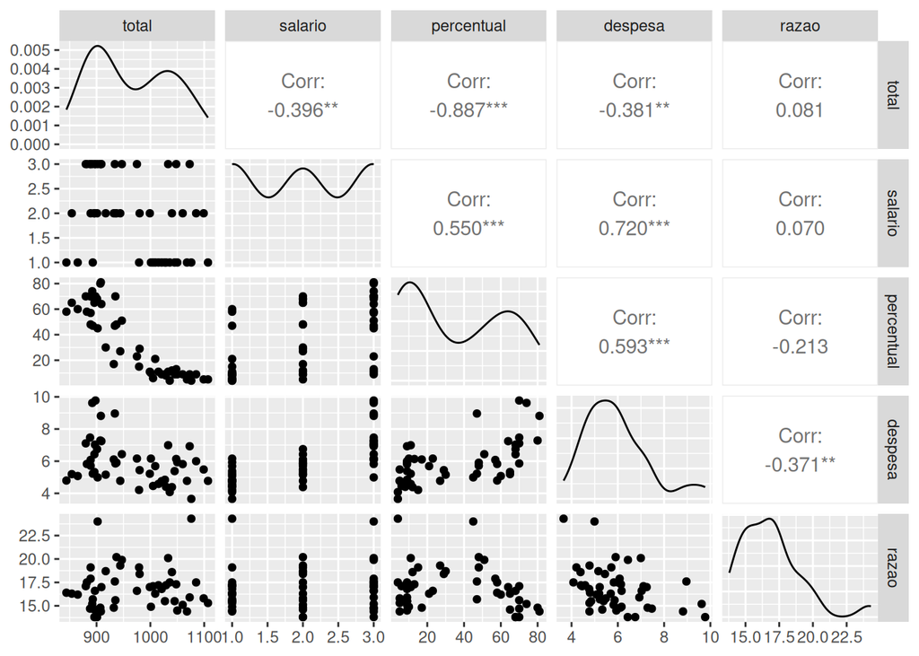

A tabela Tabela 2 reforça essa hipótese ao apresentar uma correlação de `-0,887` entre a média total de notas e o percentual de participantes, indicando que estados com maior número de participantes tendem a apresentar médias mais baixas. Também é possível observar uma correlação positiva relevante entre despesa e percentual de participantes `0,593`, sugerindo que estados com maiores investimentos em educação possuem maior percentual de participantes aptos. Em relação ao salário dos professores, a correlação com a média total de notas foi de `-0,396`, demonstrando que salários mais elevados não impactam diretamente na qualidade da nota. Por fim, a variável razão não apresentou significância estatística suficiente nesta base de dados.

Essa análise inicial será aprofundada nas próximas etapas do trabalho, por meio do treinamento dos modelos e da investigação mais detalhada da relação entre quantidade de participantes e média das notas.

## Treinamento do modelo

Com base nas conclusões tiradas na análise dos dados, vamos utilizar um modelo de regressão linear:

$$ytotal_i = \beta_0 + \beta_1 salario_i + \beta_2 percentual_i + \beta_3 despesa_i + \varepsilon_i$$

**Código**

```r
modelo <- lm(total ~ salario + percentual + despesa, data=dados)
summary(modelo)
```

```
Call:
lm(formula = total ~ salario + percentual + despesa, data = dados)

Residuals:
    Min      1Q  Median      3Q     Max
-88.428 -22.544   1.787  18.796  69.098

Coefficients:
            Estimate Std. Error t value Pr(>|t|)
(Intercept) 994.1738    22.3167  44.548   <2e-16 ***
salario       0.8538     8.3133   0.103   0.9186
percentual   -2.8560     0.2229 -12.812   <2e-16 ***
despesa      11.9696     5.2679   2.272   0.0278 *
---
Signif. codes:  0 '***' 0.001 '**' 0.01 '*' 0.05 '.' 0.1 ' ' 1

Residual standard error: 32.81 on 46 degrees of freedom
Multiple R-squared:  0.8195,    Adjusted R-squared:  0.8077
F-statistic: 69.62 on 3 and 46 DF,  p-value: < 2.2e-16
```

Com a saída da função `summary`, podemos observar que, embora a variável salário apresente um valor de correlação relativamente elevado, ela não demonstrou significância estatística no modelo. Considerando que o objetivo deste estudo é encontrar o modelo que melhor se ajuste aos dados analisados, a variável salário será removida e o modelo será treinado novamente.

Após o novo treinamento, a avaliação será realizada com base nos indicadores AIC, BIC e R2 ajustado, permitindo identificar o modelo com melhor capacidade de ajuste e equilíbrio entre desempenho e complexidade.

**Código**

```r
modelo_com_salario <- lm(total ~ salario + percentual + despesa, data = dados)
modelo_sem_salario <- lm(total ~ percentual + despesa, data = dados)

modelos <- list(
  "Com salário" = modelo_com_salario,
  "Sem salário" = modelo_sem_salario
)
```

**Código**

```r
library(broom)

bind_rows(
  lapply(modelos, glance),
  .id = "modelo"
) |>
  select(modelo, r.squared, adj.r.squared, sigma, AIC, BIC, p.value) |>
  kable()
```

Tabela 3: Comparação dos modelos ajustados.

| modelo | r.squared | adj.r.squared | sigma | AIC | BIC | p.value |
| --- | --- | --- | --- | --- | --- | --- |
| Com salário | 0.8195140 | 0.8077431 | 32.80665 | 496.7879 | 506.3480 | 0 |
| Sem salário | 0.8194726 | 0.8117906 | 32.45949 | 494.7994 | 502.4475 | 0 |

Com base nos resultados obtidos, podemos afirmar que a variável salário não apresentou significância estatística suficiente para explicar adequadamente os dados analisados. Essa conclusão torna-se ainda mais evidente ao observar a saída da função `summary` no novo modelo, em que a remoção dessa variável não comprometeu a capacidade explicativa do modelo.

**Código**

```r
summary(modelo_sem_salario)
```

```
Call:
lm(formula = total ~ percentual + despesa, data = dados)

Residuals:
    Min      1Q  Median      3Q     Max
-88.400 -22.884   1.968  19.142  68.755

Coefficients:
            Estimate Std. Error t value Pr(>|t|)
(Intercept) 993.8317    21.8332  45.519  < 2e-16 ***
percentual   -2.8509     0.2151 -13.253  < 2e-16 ***
despesa      12.2865     4.2243   2.909  0.00553 **
---
Signif. codes:  0 '***' 0.001 '**' 0.01 '*' 0.05 '.' 0.1 ' ' 1

Residual standard error: 32.46 on 47 degrees of freedom
Multiple R-squared:  0.8195,    Adjusted R-squared:  0.8118
F-statistic: 106.7 on 2 and 47 DF,  p-value: < 2.2e-16
```

## Diagnóstico do modelo

Os gráficos sobre os resíduos do modelo final são apresntados na figura Figura 1. De modo geral, os resíduos não indicam violações graves dos pressupostos de linearidade, normalidade e homocedasticidade. Há algumas observações com maior distância de Cook, mas a influência não parece comprometer a conclusão principal do modelo.

**Código**

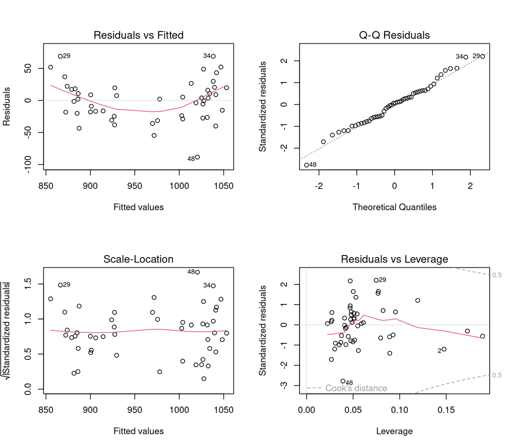

Figura 1: Gráficos de diagnóstico do modelo final.

```r
modelo_final <- modelo_sem_salario

par(mfrow = c(2, 2))
plot(modelo_final)
par(mfrow = c(1, 1))
```

Os testes formais também não apontam problemas relevantes nos resíduos. O teste de Shapiro-Wilk não rejeita a normalidade dos resíduos, e o teste de Breusch-Pagan não rejeita a hipótese de variância constante.

**Código**

```r
library(lmtest)
library(zoo)


shapiro.test(residuals(modelo_final))
```

```
    Shapiro-Wilk normality test

data:  residuals(modelo_final)
W = 0.98501, p-value = 0.772
```

**Código**

```r
bptest(modelo_final)
```

```
    studentized Breusch-Pagan test

data:  modelo_final
BP = 0.41351, df = 2, p-value = 0.8132
```

## Conclusão

Após a análise, podemos observar que, caso utilizássemos apenas a estatística descritiva, poderíamos chegar a conclusões equivocadas sobre os dados. A variável de maior impacto no conjunto analisado foi o percentual de alunos aptos a realizar a prova, variável está diretamente relacionada às despesas dos estados com educação.

Em uma análise superficial, seria possível supor que estados com maiores gastos apresentam notas médias menores. Entretanto, ao aprofundar a investigação e compreender melhor o contexto dos dados, percebe-se que estados com maior investimento em educação tendem a ampliar o acesso à prova, permitindo a participação de um número maior de alunos, independentemente do nível de desempenho individual. Por outro lado, estados com menor investimento acabam restringindo a participação, concentrando-a em alunos com maior poder aquisitivo ou com maior probabilidade de ingresso no ensino superior.

A variável faixa salarial apresentou relação com a pontuação dos alunos, porém não manteve relevância estatística no modelo múltiplo. Isso sugere que o efeito do salário pode estar mais associado às despesas educacionais dos estados e à quantidade de participantes do que diretamente ao desempenho médio obtido.

Por fim, a variável razão não se mostrou estatisticamente significativa neste conjunto de dados. Contudo, isso não significa que a quantidade de alunos não impacte a qualidade do ensino. A principal conclusão é que, especificamente para está base analisada, não foram encontradas evidências estatísticas suficientes para confirmar essa relação de maneira significativa.

Agora sobre o modelo selecionado, ele explica aproximadamente 82% da variação observada na pontuação média total, com R2 ajustado de aproximadamente 81%. Os diagnósticos dos resíduos não indicaram violações graves dos pressupostos da regressão linear.

Conclui-se que o percentual de participação deve ser considerado indispensável em qualquer análise desse banco de dados. Sem esse controle, a relação entre investimento educacional e desempenho pode ser interpretada de forma equivocada. Após controlar a participação no exame, a despesa por aluno aparece positivamente associada à pontuação média no SAT.

Por se tratar de um estudo observacional com dados agregados por estado, os resultados não devem ser interpretados como relações causais definitivas. Variáveis não observadas, como renda familiar, composição socioeconômica, políticas estaduais de admissão universitária e preferência regional pelo SAT ou por outros exames, podem influenciar simultaneamente a participação e o desempenho. Ainda assim, o modelo ajustado fornece uma explicação estatística coerente e evidencia a importância de controlar fatores de seleção ao comparar médias educacionais entre estados.